# Systematic review of Acceptability Judgment Studies

Preliminary summary statistics

Published

February 2, 2026

This is just a (not so) quick overview of where we stand with coding, and some observations about what we’ve found so far.

# Where we are with annotations

So far we’ve annotated 95 (31%) articles, containing a total of 174 individual acceptability judgment (AJ) studies.

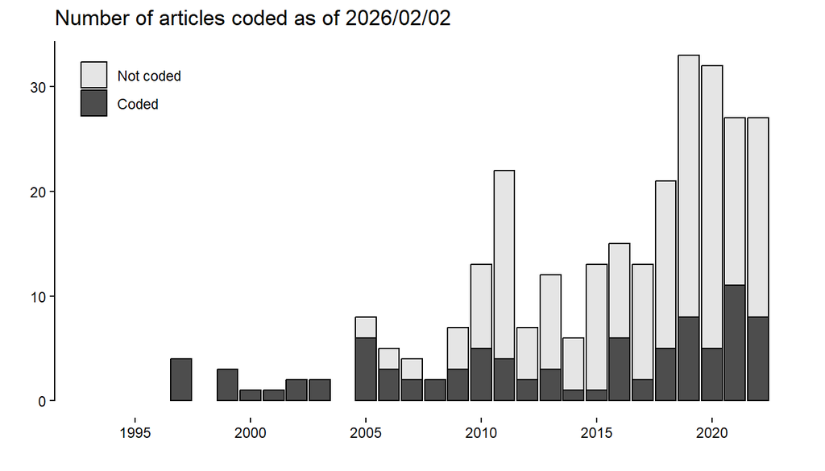

Figure 1: Numbers of AJs in these journals have been increasing since the 2010s.

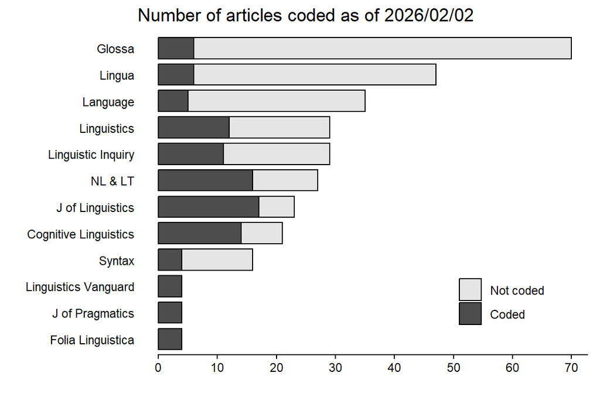

Figure 2: We’ve still got some journals to catch up on!

# Summary stats from what we’ve coded

Reporting practices are highly variable, as we know. The quality of reporting is especially dodgy for the earlier studies. This is partly due to the novelty of these methods, but also to overly ambitious papers. I coded a 2005 *Syntax* paper by Frazier and Clifton that reported 11 different experiments, five of which were acceptability judgment tasks of some kind! And these are very prominent people in their field, so it’s not hard to see how problematic habits get propagated.

The most commonly investigated languages so far are English and German, although we still need to check the “Not Reported” cases. Many of the English studies do not explicitly report that they are on English, naturally.

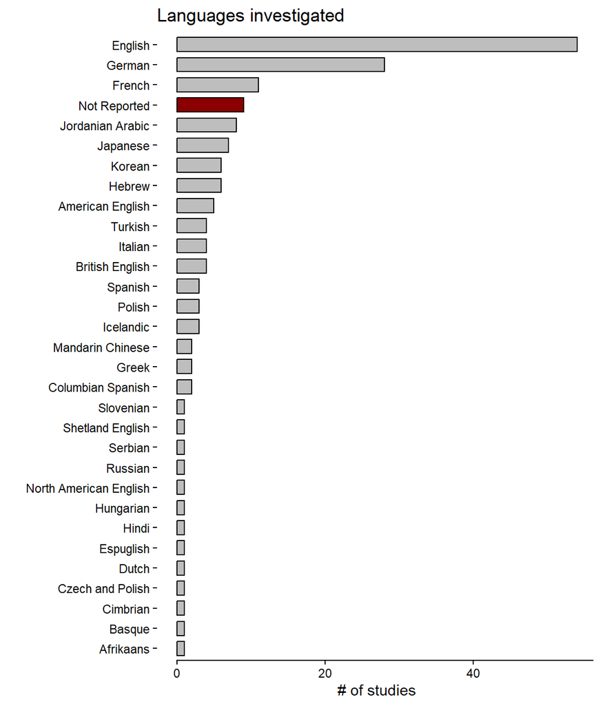

Figure 3: What language did the study investigate?

I’ve broken down some key aspects in the sections below.

## Participant information

We’ve had several studies (N = 12) for which the number of participants was not fully clear. For those that do report numbers, we find that **most studies involve fewer than 50-60 participants** (median = 44), but there are some with huge numbers. May need to check those.

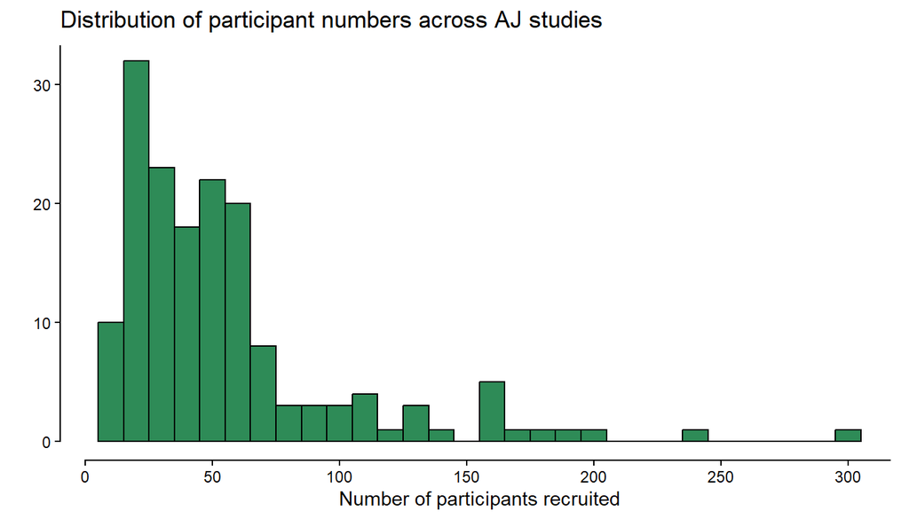

The tabs below show the distributions of how populations, recruitment methods, compensation, and demographic information were reported.

**Population**

University students are the most common source of participants by far. I’m curious that so many studies don’t report where participants come from. We should double check these.

One thing to review is how we’re coding populations from online platforms like AMT and Prolific. Should these be coded as “Mixed” or “Not Reported”, or something else like “Unknown (online)”?

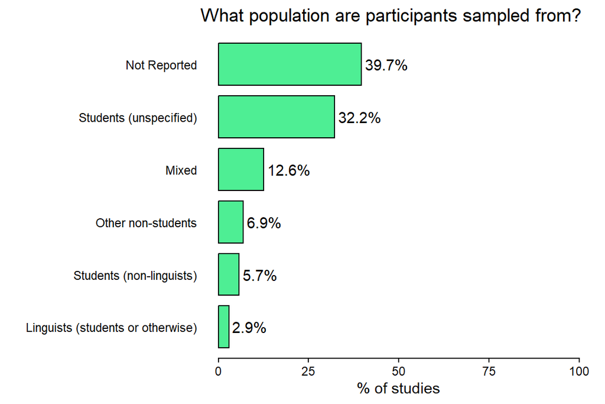

Figure 5: Over a third of studies don’t mention where participants come from.

**Recruitment**

As expected, university affiliation (students and/or staff) is the most common way to get participants, but I suspect online platforms will be more common as we annotate more recent studies.

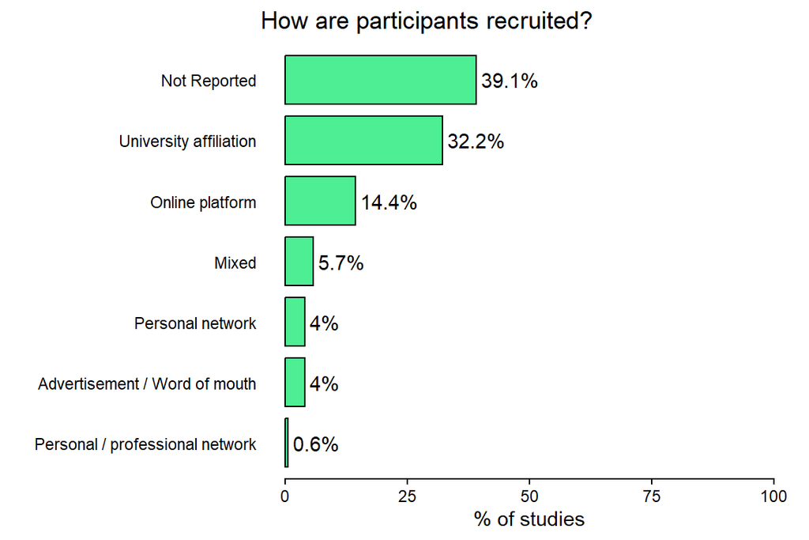

Figure 6: Participant recruitment details are surprisingly under-reported.

**Compensation**

Compensation is not reported very often. It’s worth remembering that online platforms often pay participants directly, so this may be assumed by authors. But it should be explicitly reported (and often is).

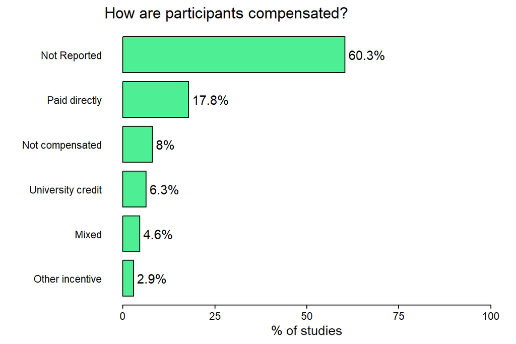

**Demographics**

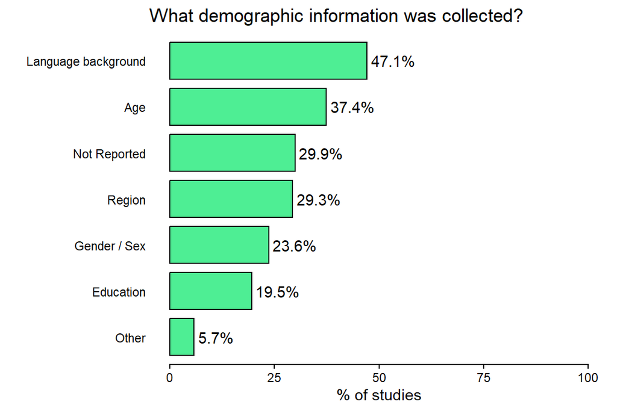

Figure 8: Many studies don’t bother mentoioning anything.

## Design features

Most studies focus on syntax, not surprisingly. In many cases, the line between morphology and syntax or syntax and semantics is a bit blurry, but this is not really a main focus, so…

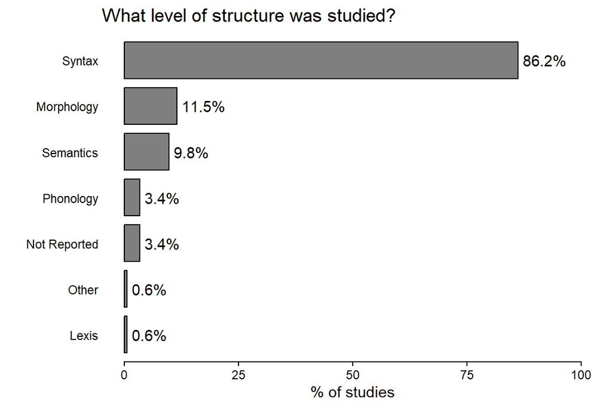

Figure 9: Naturally syntax is the most common focus.

**Explicit reporting of design features**, such as exact numbers of items and exact numbers of conditions, **is not very consistent**.

**Stimuli**

Exact numbers of stimulus items can often be reconstructed/deduced from information in the article with varying degrees of effort and certainty, but readers ideally should never have to do this.

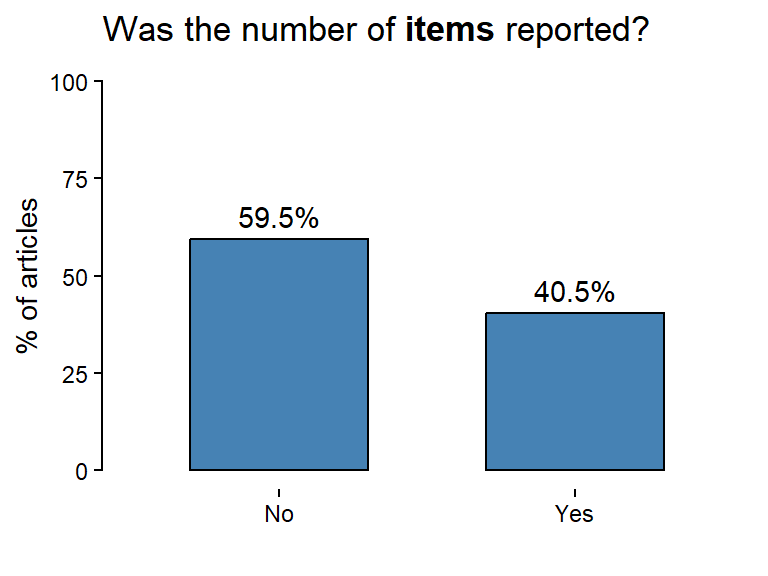

Figure 10: Studies do not report the exact numbers of (critical) experimental **items** clearly enough.

**Experimental conditions**

Similarly, the exact number of experimental conditions is not consistently reported, although the design can often be reconstructed from the description. Studies often report individual factors and/or design structure (e.g. “We used a 2x3 design crossing factor A with factor B”) but then leave the reader to compute the final total.

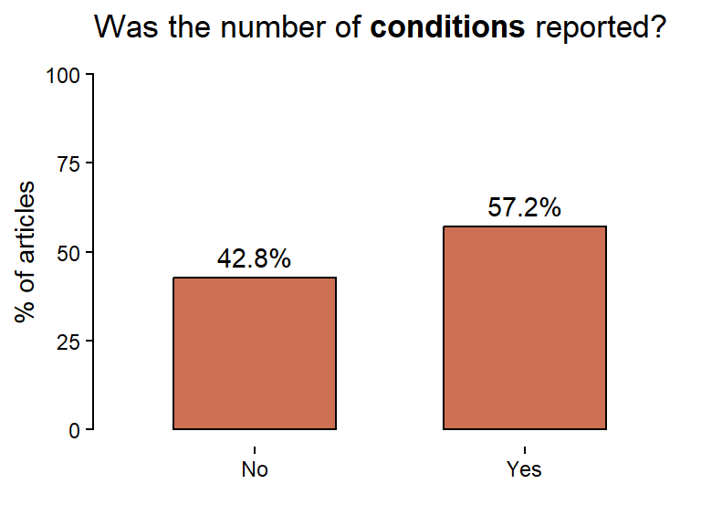

Figure 11: Studies do not report the exact numbers of experimental **conditions** clearly enough.

Reporting of exact numbers has improved considerably over time, though. Many of the early studies (pre 2010) have been coded, so you can already see the trends over time in what we’ve coded so far:

**Stimuli number reporting**

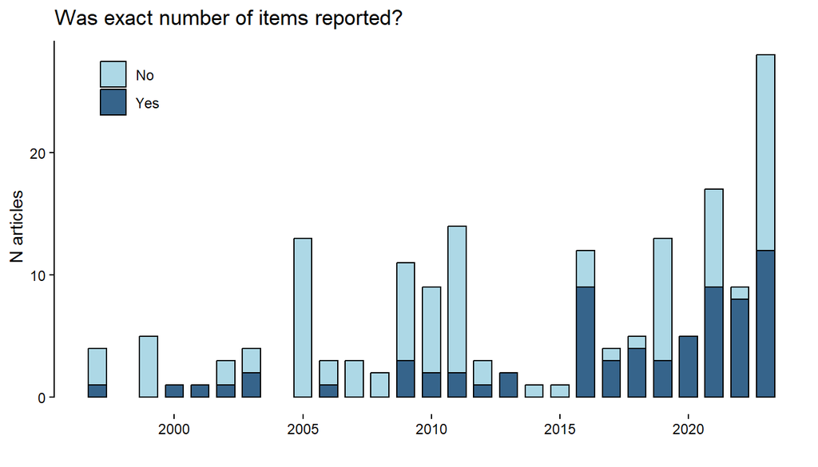

Figure 12: Studies are becoming much more consistent in reporting exact item numbers.

**Experimental condition number reporting**

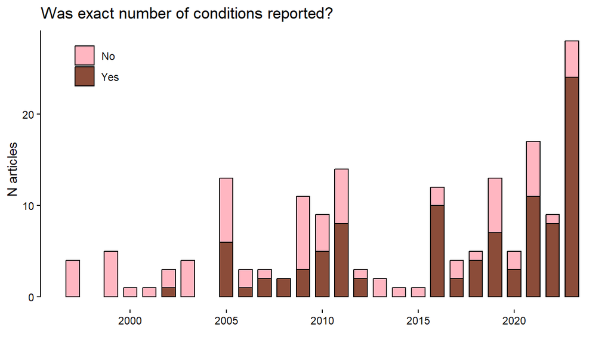

Figure 13: Studies are becoming much more consistent in reporting exact condition numbers.

The number of experimental conditions used in the studies’ design varies widely, but this variability has not changed over time:

**Condition count distribution**

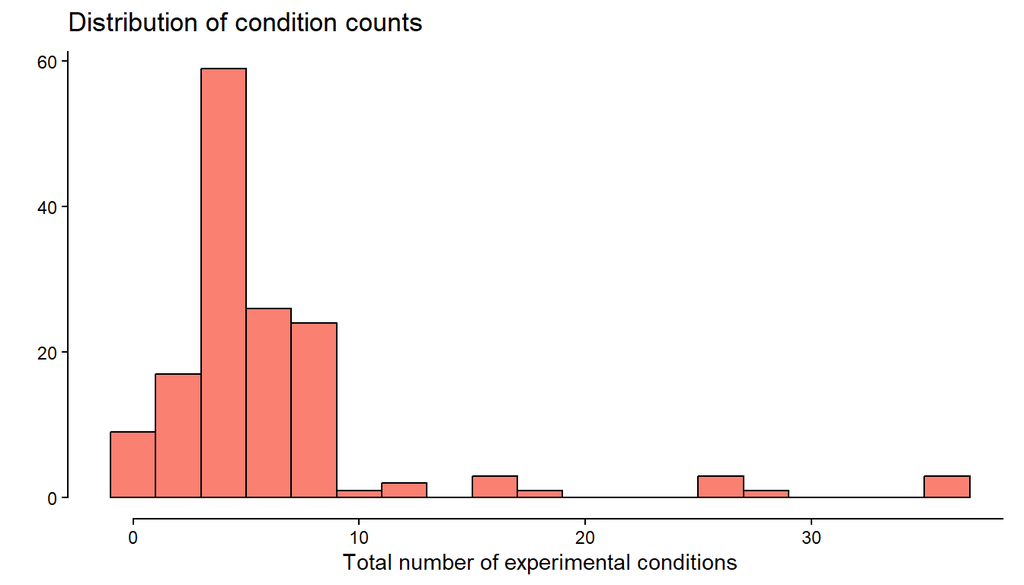

Figure 14: Numbers of conditions vary a lot across studies.

**Condition count by year**

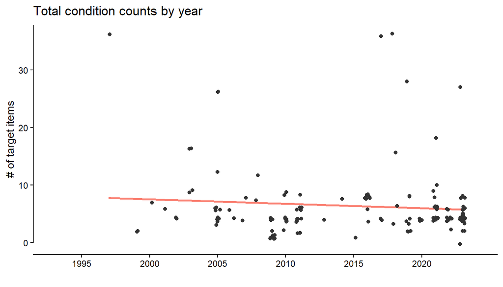

Figure 15: Number of conditions has not changed much over time.

Same goes for stimulus items:

**Item count distribution**

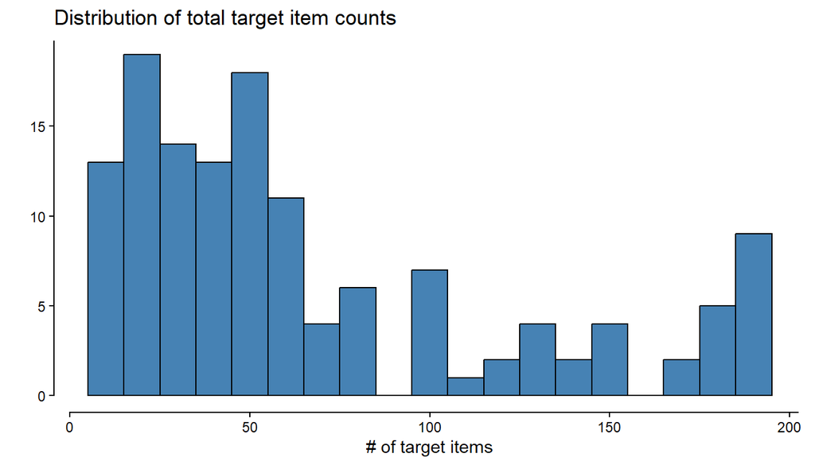

Figure 16: Numbers of target items vary a lot across studies.

**Item count by year**

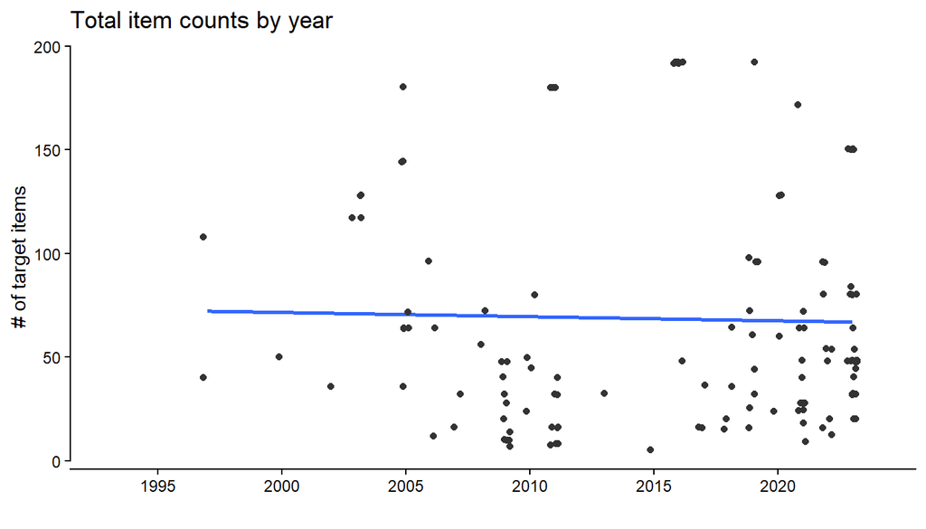

Figure 17: Number of target items has not changed much over time.

**Items per condition**

The **number of items per condition** (min = 1, median = 10, max = 64) is an important aspect of study design, as it directly relates to the power of the study.

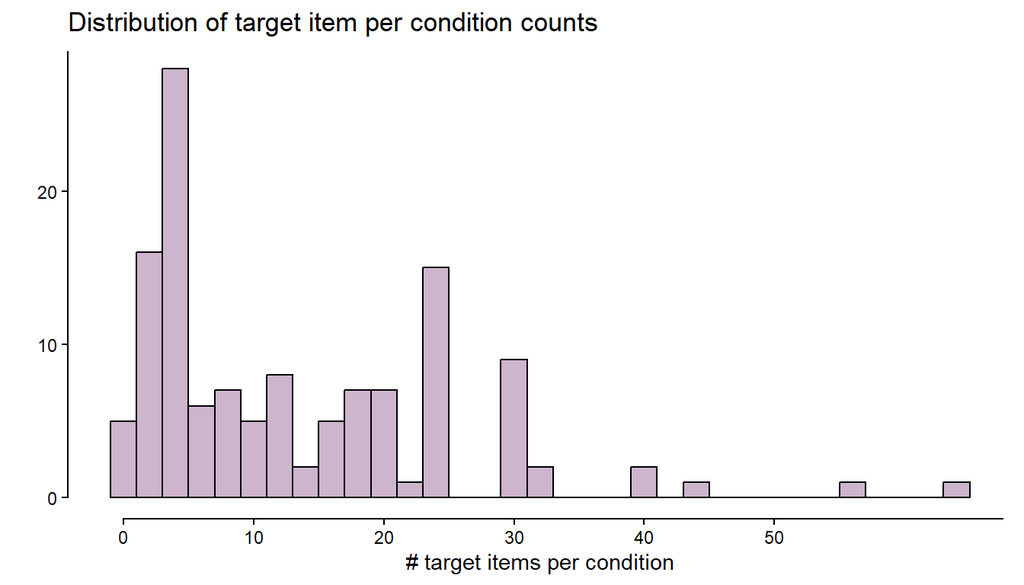

Figure 18: Numbers of target items per condition vary a lot.

**Items per condition by year**

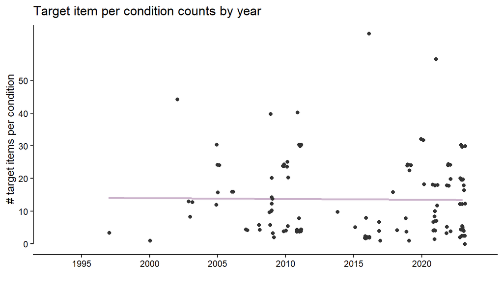

Figure 19: Numbers of target items per condition has not changed much over time.

### Item construction

We may need to check our annotations, but many studies do not explicitly state how items were constructed; they just assume it is clear.

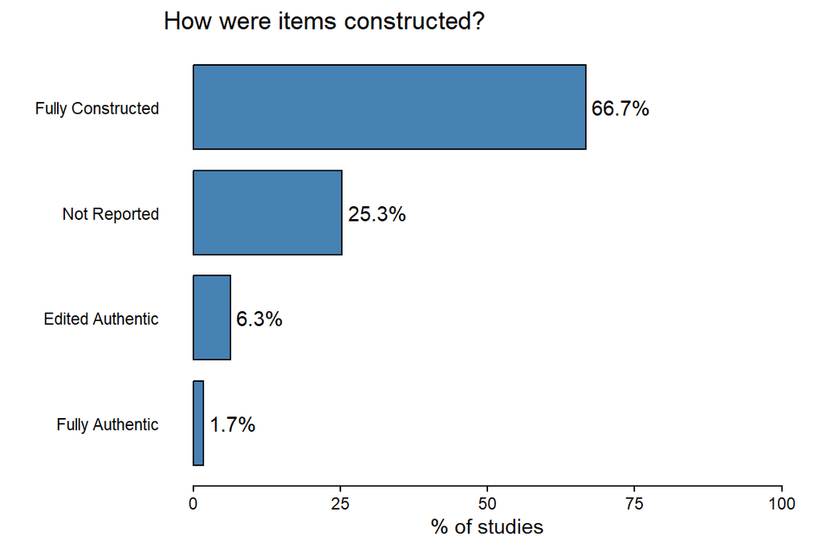

Figure 20: Most stimulus items were constructed by researchers.

## Task features

### Rating scale

Ordinal ratings (likert) seems to be the most popular method by far. we’ll need to check the “not Reported” cases…

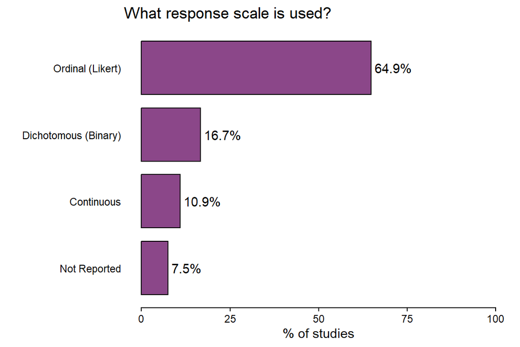

Figure 21: Ordinal scales are the most common.

Odd numbered scales (5, 7) seem to be the most popular:

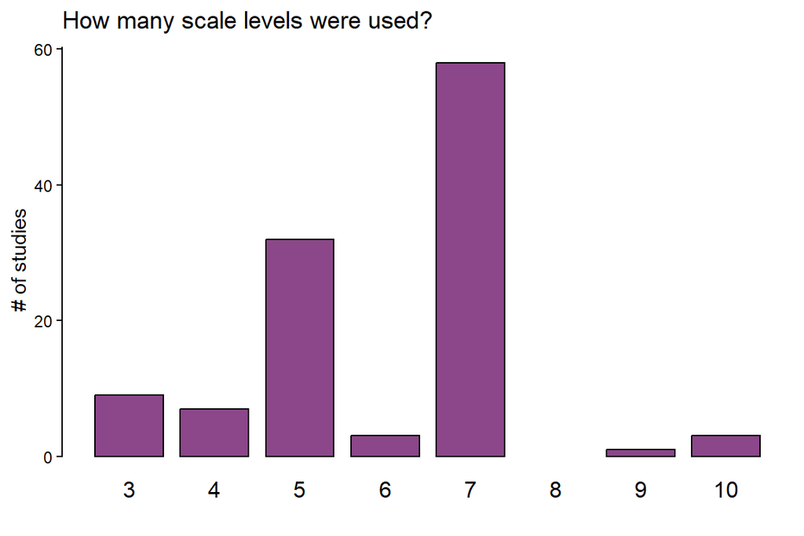

Figure 22: Odd numbered scales are the most common.

### Task modality

Most studies were based on written tasks, yet this is not always clear. Many studies leave this information implicit, e.g. as it is assumed in the use of an online survey, and we may have coded these a bit inconsistently. I suspect that for many of the studies coded as “written”, the modality was not explicitly reported.

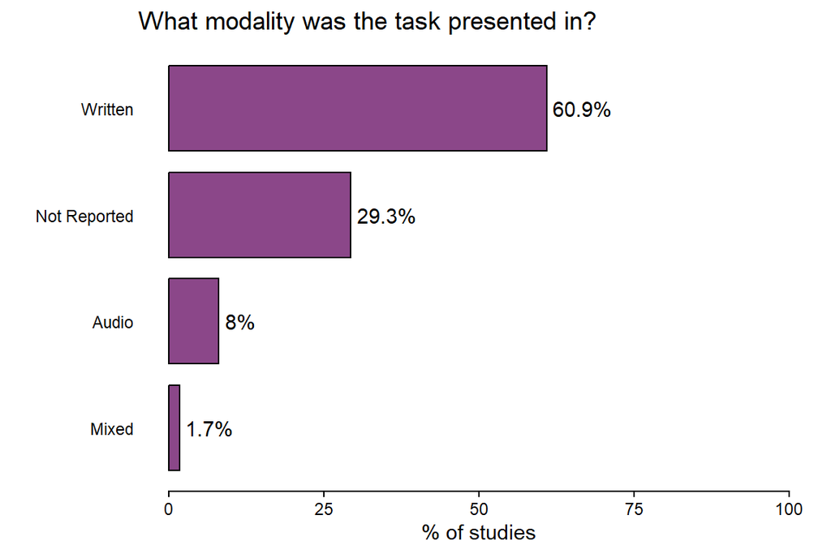

Figure 23: Most tasks are certainly text-based (written) but this is not always stated clearly.

### Task instructions

The exact instructions given to participants are rarely provided, especially in early studies. But based only on *authors’ descriptions/paraphrases* of the instructions it’s clear that “acceptability” is the most common label used. “Correctness” is by far the least common label.

This is a very fuzzy coding system, as we have to either (a) rely on the authors’ paraphrase of the task instructions, which may be inaccurate, or (b) code any cases lacking the exact instructions as “Not Reported”. I’d like to go back and add a code for whether the exact instructions were provided by the authors (adding it now may mess up the app).

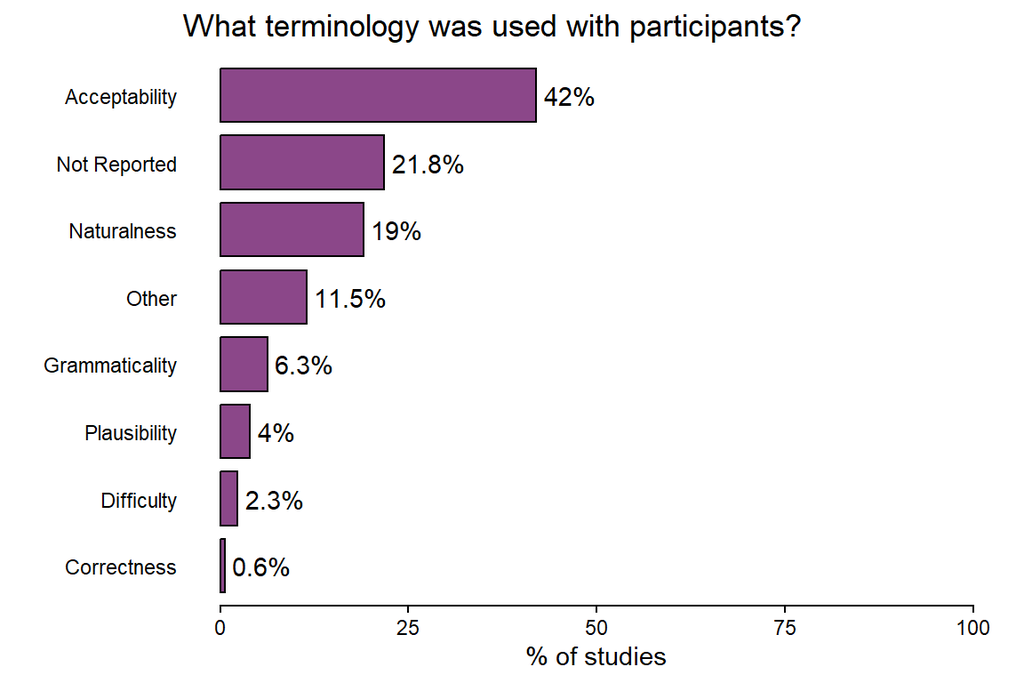

Figure 24: Acceptability is the most common label used, but this is largely based on author paraphrases rather than exact instructions.

### Other aspects

Very few studies included confidence measures, or comprehension tasks. We can look into those later.

## Analysis features

**Preprocessing** (e.g. *z*-scoring, log-transforming) of the data is not as common as I thought.

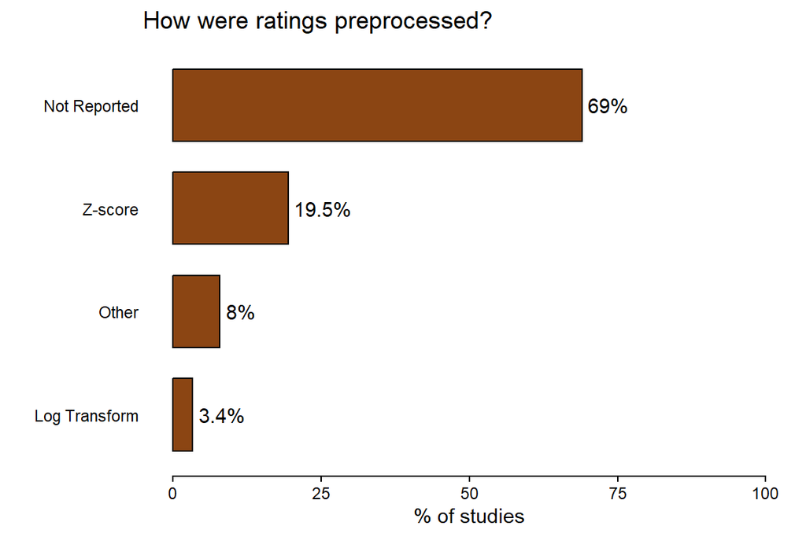

Figure 25: Most studies do not report any preprocessing of the data.

Statistical analsis of different kinds of data varies some in the use of methods that are suited to the scale(s) of the data. Ordinal data are especially likely to be analysed as continuous.

**Ordinal data**

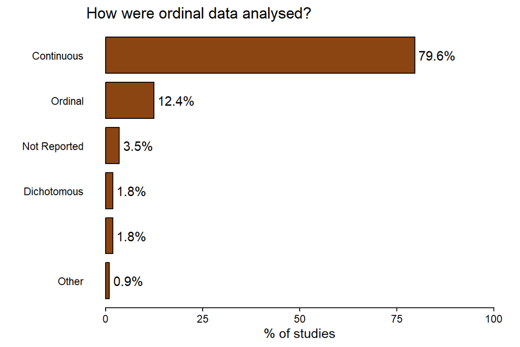

Figure 26: Ordinal data are commonly analysed as continuous data.

**Dichotomous data**

Fortunately, dichotomous data (N = 29) are more likely to be analysed appropriately.

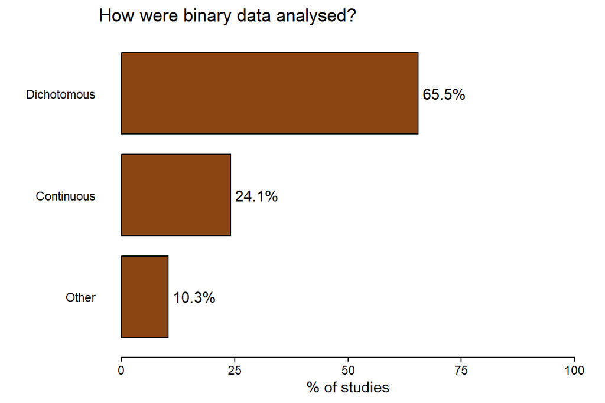

Figure 27: Dichotomous data are usually analysed as dichotomous (good) or as proportions (not as good).

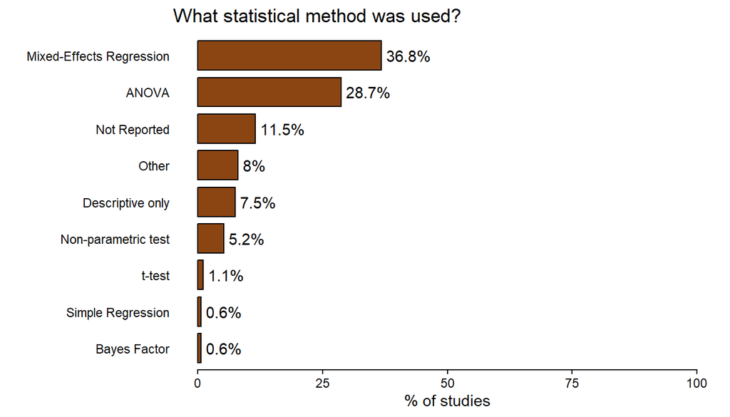

Figure 28: Many ANOVAs also are done by-item and by-participant.

No surprise, R is the most common reported software, and this number will surely increase as we code more recent articles (although this depends on whether authors report the tools they used).

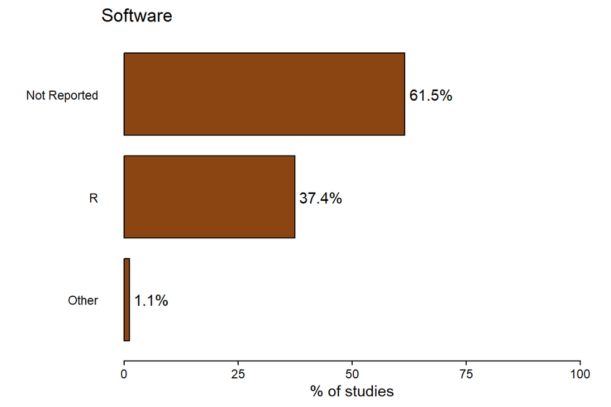

Figure 29: What analysis software was used?

Still, very few studies report effect sizes, but we need to check this. To be clear, **regression model coefficients are considered measures of effect size**, with some caveats.

Almost no studies do any kind of follow-up analysis of autocorrelation or individual participant analysis. Few studies even report item- or participant-level variances in their result summaries.

## Reproducible practices

Here are the data for how studies provide the materials, data, and code. **Only 1 article coded so far was preregistered**.

About half of articles coded thus far do not provide the complete list of experimental items used in the study. The vast majority still do not report data and/or code, however.

One thing I’ve noticed is that even the few studies that do provide the R code often do not provide the raw data from the experiment. Data and Code should have been separate annotation codes in hindsight. But easy enough to check afterwards.

**Stimuli**

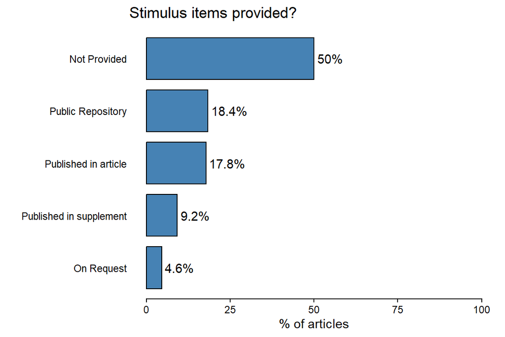

Figure 30: Most still do not provide all items.

**Data & Code**

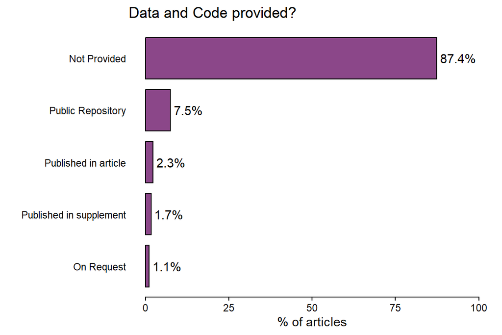

Figure 31: Provision of full data and code is still not common.

# Miscellaneous observations

Here are just some thoughts about things as I’ve been doing this. All boldfaced bits in the quotes that follow are mine.

## Vague or confusing descriptions

It’s painfully clear by now that the field has done a horrible job with reporting details of AJ studies. I’ve just collected a few cases for illustration, often from prominent people in the field.

Here’s an early example from Bhatt (1997). How many contraints (conditions) were investigated in this study?

> “There were 40 items designed to cover most of the syntactic constraints proposed in the literature, such as, the Government constraint (Di Sciullo et al., 1986), the Functional Head constraint (Belazi et al., 1994), the Equivalence constraint (Poplack, 1980), and the System Morpheme and the Island constraints (Myers-Scotton, 1993a).”

Or from Featherston (2005b)—are there 32 or (8 x 32) = 256 total items?

> “Subjects thus saw **thirty-two experimental sentences** in total (2 extraction types x 2 complement clause types x 8 matrix verbs). These experimental materials were **implemented in eight different lexicalizations**, so that each subject saw a version of the materials such that each experimental condition appeared once and each lexicalization appeared four times.

Another from a different Featherston (2005a) paper:

> “In order to test for superiority, **we tested twenty-six di¤erent multiple wh-question structures**, hoping thus to establish whether German has such an effect, and if so, which combinations of grammatical functions as wh-items would trigger it. Twenty-six sentences of the form of (7) were constructed, such that **each could be transformed into the multiple wh-questions we tested**.” (p.678)

So again, how many unique stimulus token sentences were there: 26 or (26 x 26) = 676? There’s no way they asked participants to rate ~700 sentences!

Or from Pasquereau, Dillon & Frazier (2023), where description of items is unclear:

> We developed **18 sets of experimental items**, each set consisting of the three experimental conditions shown in table 2. The experiment involved three conditions varying along two factors:grammaticality and presence of a quantifier. The **18 critical experimental items** were combinedwith 23 filler sentences. (p.14, emphasis mine)

Were there 18 individual items/sentences, or 18 *sets* of three items/sentences each, i.e. 54 total critical items?

I wonder whether we can include excerpts from papers in our presentation/write-up of the results. It seems a bit cheeky to single people out, but it’s important to highlight just how pervasive this is (was). I suppose we could ask for permission from authors themselves just to be professional about it.

## Over-complicated designs

Many early studies involve very complicated designs or tasks. For instance, Dąbrowska (2008) writes:

> “The experiment described in this paper was designed to investigate how each of these three factors [subject, verb, auxiliary] individually contributes to speakers’ judgment. It will also examine two additional grammatical factors: the presence or absence of a complementizer and the number of clauses intervening between the WH word and the gap, as well as the effects of plausibility and syntactic complexity.”

There were seven experimental conditions included according to the paper. How does this number follow from the above description?

Another example (Güneş & Lipták 2020), included three separate tasks in one survey: a forced choice task, a likert-scale acceptability rating task, and a binary yes/no acceptability task. This is unusual in many ways, and I coded this as three separate experiments. But the combination of tasks in one survey could surely impact the results in ways that were not explored in the paper.

## Conflicting information

As mentioned above, what is described in the paper is not always an accurate picture of what was done. This is especially true with the reporting of **participant instructions**. I found a surprising example of this from Francis (2010), where information reported in the text is not consistent with what was actually done. From the in-article description:

> “The survey consisted of a series of sentences for which participants were asked to rate each sentence on 9-point scale, **where 9 means ‘completely acceptable’ and 1 means ‘completely unacceptable’** (see Appendix B for exact instructions).” (p20)

But if we look at the verbatim instructions in the Appendix:

> “Please read each of the sentences listed below. For each sentence, we would like you to indicate your reaction to the sentence. Mark your response sheet by circling a number from (1) to (9). Use (9) for sentences that seem fully **normal**, and **understandable** to you. Use (1) for sentences that seem very **odd, awkward, or difficult for you to understand**. If your feelings about the sentence are somewhere between these extremes, use one of the middle responses from (2) to (8). Please try to use the entire scale, not just the end points of the scale.”

So participants were *not* actually asked about ‘acceptability’ at all, but about what is ‘normal’ or ‘understandable’.

I think this is a bigger issue with respect to the **inconsistency in how the field views and treats the construct of acceptability** itself. The assumption is that non-linguists’ conceptions of “naturalness” or “goodness” in language align with what linguists mean by ‘Acceptability’, and hence *how we describe what participants were asked to do* isn’t seen as important. But I’m not sure this has been explored very thoroughly.

At the very least, our descriptions should more accurately describe what was actually done in the experiment. Providing the exact instructions would make a big difference in this regard.

## No details of filler items

Lastly, most studies include filler/distractor items but information about these items—including the numbers used and how they were constructed/chosen—is highly variable, and most studies rarely offer any specifics. Studies almost **never provide any explanation or justification for the numbers of fillers included**, although they may report some basic facts about what they involved and balance across acceptability. Even when target items are provided, fillers are often not.

Whether this really matters is up for debate, I suppose, but the inconsistency in how we treat this aspect is yet another indication of poor communication of good experimental practices.

## References

Bhatt, Rakesh Mohan. 1997. Code-switching, constraints, and optimal grammars. *Lingua. International review of general linguistics. Revue internationale de linguistique générale* 102(4). Elsevier BV. 223–251. doi:10.1016/s0024-3841(97)00007-7.

Dąbrowska, Ewa. 2008. Questions with long-distance dependencies: A usage-based perspective. *Cognitive Linguistics* 19(3). Walter de Gruyter GmbH. doi:10.1515/cogl.2008.015.

Featherston, Sam. 2005a. Universals and grammaticality: Wh-constraints in German and English. *Linguistics* 43(4). Walter de Gruyter GmbH. doi:10.1515/ling.2005.43.4.667.

Featherston, Sam. 2005b. That-trace in german. *Lingua. International review of general linguistics. Revue internationale de linguistique générale* 115(9). Elsevier BV. 1277–1302. doi:10.1016/j.lingua.2004.04.001.

Francis, Elaine J. 2010. Grammatical weight and relative clause extraposition in English. *cogl* 21(1). Walter de Gruyter GmbH. 35–74. doi:10.1515/cogl.2010.002.

Güneş, Güli̇Z & Anikó Lipták. 2020. Nuclear prominence in ellipsis: Evidence from aggressively non-D-linked phrases. *Journal of Linguistics* 57(1). Cambridge University Press (CUP). 83–121. doi:10.1017/s0022226720000134.

Pasquereau, Jérémy, Brian Dillon & Lyn Frazier. 2023. Quantification at a distance and grammatical illusions in French. *Syntax (Oxford, England)*. Wiley. doi:10.1111/synt.12260.